# Final Project for the course: 2020/21/2 DPSZ16-KVAN-106 1

Alex Ilyés

2021 04 09 - 2021 06 11

# Loading in the data

For this final assingment project, I will use the Anime dataset from TidyTuesday’s 2019-04-03 occasion:

This dataset contains every anime listed on the MyAnimeList.org website, which is the most popular site for rating and logging animes, visited not only by fans, but a more mainstream audience too. The most important data the set contains are: - The name of the anime, - The studio that produces it, - The year and season it released in, - The number of episodes in a series, - The average runtime of one episode (or the runtime of a movie), - The number of people who scored, favorited or watched that anime, - The average score it received from the viewer base, - The age rating it was categorized under, - And two rank measures: the Rank based on weighted score, and the Popularity based on how many people interacted with the anime.

# Data Cleaning

First, I clean our data to have an adjusted dataset that is suitable for later analysis. To this end, I do some filtering and modification: - I am only interested in anime TV series, so I will filter out movies - I am only interested in which year and season it premiered - derived from “premiered” - For one anime there are multiple producers, but the most important contribution is from the animating studio. Therefore I do not want to have the data duplicated for each producer and studios, so I aggregate those variable. For modelling analysis, I will only deal with animes that have one animating studio. - Also, there is an entry for every genre under the same title, I will also collapse this and only use the number of different genres, and I will call that a “diversity” measure. - I also remove “min per ep” from the runtime

```
## [1] 280
```

## Cleaning for modelling

After the initial cleaning, for exploratory analysis I will use the long or the aggregated version of the data. For the modelling part, I further check the histograms of the data:

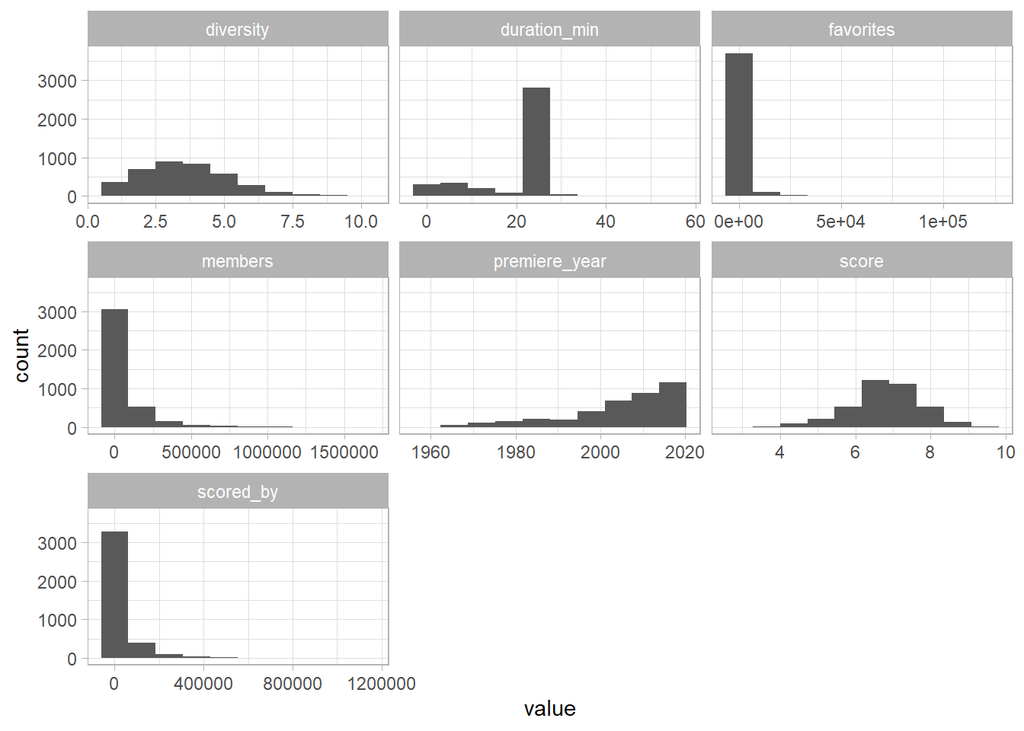

Based on the histograms, I can see some anomalies - Duration is mostly around the 20 min mark, which makes sense, as it is the standard anime runtime. - More and more animes premiere each year, with a very low amount of anime produced before 2000s - There are some animes that are scored and favoured by extrememly many people - these animes are probably the ones that “got mainstream” and are not only watched by anime “otakus” (experts of anime), but casual watchers. But also, there are huge amount of animes that do not get much traction, these are only known by their own fanbase.

For modeling, I would like to use a less heterogenous and chaotic dataset, to be able to asnwer more specific questions. To this end I further investigate varables, starting with runtime.

```
## # A tibble: 44 x 2
##    duration_min     n
##    <fct>        <int>
##  1 24            1311
##  2 23             705
##  3 25             639
##  4 5              192
##  5 3              146
##  6 22             110
##  7 2               81
##  8 1               67
##  9 4               65
## 10 20              64
## # ... with 34 more rows
```

Based on the count, we can see that the standard anime run time is 24 min (+- 1 min). I could categorize the data into standard, short and long animes, but it would not be that informative, as categorization would be arbitrary, and still be uneven towards standrad duration animes. Therefore I chose to only work with animes above the 20 minute mark and under 27, and not use duration in modelling analysis.

I will investigate premiere_year now:

```
## # A tibble: 2 x 2
##   premiere_category   sum
##   <fct>             <int>
## 1 before-1994         721
## 2 after-1994         3124
```

I decided to work with only the animes after 1994, as this year marks the release of Neon Genesis Evangelion, which forever changed anime: https://www.youtube.com/watch?v=HcPIHPkXx6s I will filter based on the relase date of that show.

After filtering for these two variables, I will check the audience variables again:

For modeling I would like to use members (members, who have the anime in their list) as an independent variable as a proxy for how popular the anime is. However as members is skewed, I will filter it with the help of percent quntilies and some data modification.

Now I check how the filtering worked out and see the histograms

```
## # A tibble: 7 x 2
##   duration_min     n
##   <fct>        <int>
## 1 24             906
## 2 23             519
## 3 25             187
## 4 22              61
## 5 20              11
## 6 26              10
## 7 21               6
```

```
## # A tibble: 1 x 2
##   premiere_category   sum
##   <fct>             <int>
## 1 after-1994         1700
```

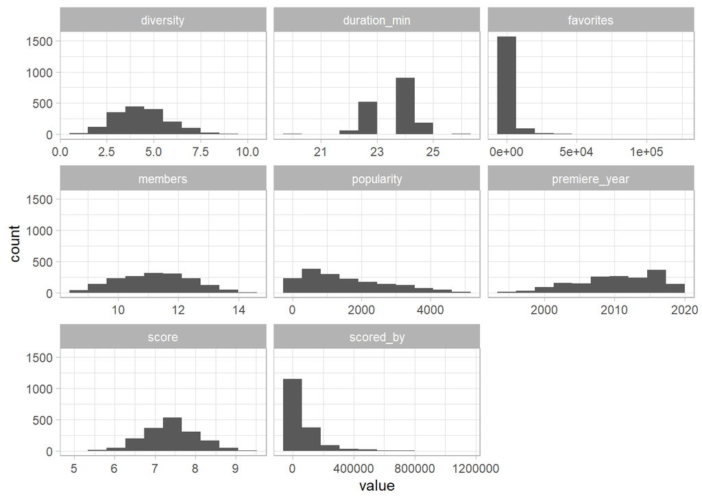

# Exploratory Analysis

First off, I do some exploratory analysis, to know more about the dataset.

I will investigate the following:

1. See the top 15 favored and scored by animes
2. See the ratio of rank-popularity: those animes that are more popular than scored high; and those that are scored high, but less popular (overrated animes vs. underrated gems)
3. Shounen, seinen frequency in years - are there more boyish or girlish years?
4. Check the genre “fingerprint” of the most popular studios (based on: https://www.youtube.com/watch?v=EHqFDXa-sH4)
5. Is anime for kids - age rating and scores?
6. Are there seasonal trends? I will do a tokenized vocabulary analysis for words that describe shows from different seasons (based on: https://www.youtube.com/watch?v=3PecUbnuYC4)

## 1. Most mainstream animes

We will check the most mainstream animes based on how many people put them amongst their favorites and how many users scored them at all.

The 15 most scored animes are shown below:

[figure not shown]

The 15 most favorited animes are shown below:

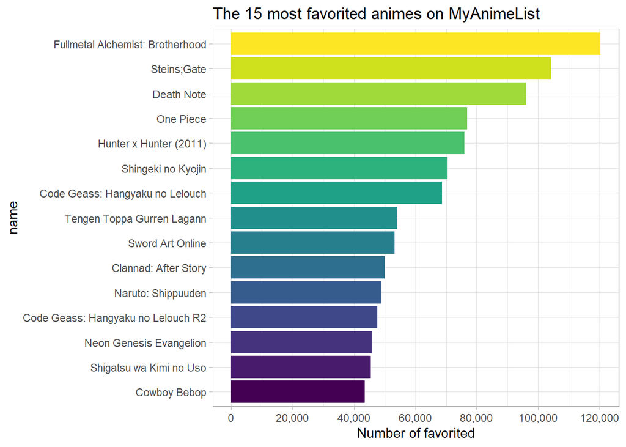

Nice! We can see some overlap: - Death Note, Full metal Alchemist, Shingeki no Kyojin, etc. these are animes that were not only very popular in Japan but also in the West

## 2. Rank vs. popularity

Both of these measures are ordinal scales that range from 1 (the best) to the number of all animes. - Rank is given by the MyAnimeList algorithm (weighing raw ratings), while - Popularity is based on how many members listed the anime as viewed.

First I show the relationship between the two ranking measurements:

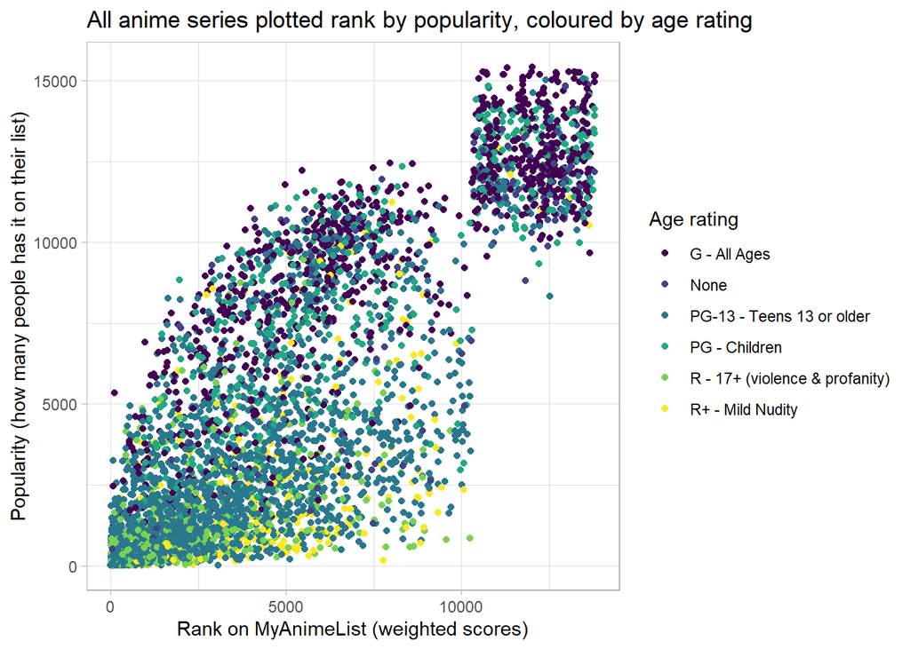

Then I show the 10 most over- and underrated animes.

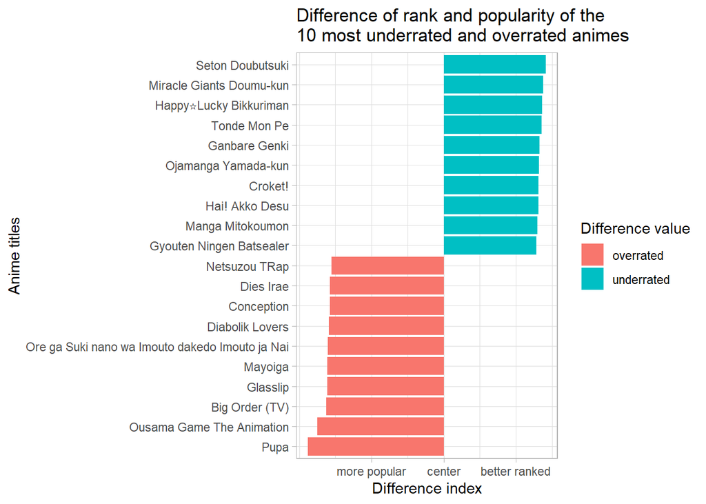

## 3. Shounen vs. shoujo over the years

There are two anime-specific genres in Japan, the Shounen and the Shoujo genre, which stand for the words “boy” and “girl” respectively. Therefore, these signify male- or female aduience oriented stories: - Shounen typically follow a young (12-18 yo.) boy through action-packed, fantastic stories about battles and trials. - Shoujo tipycally follow a young (12-18 yo.) girl through school-related, slice of life stories about romance and friendship. We could check whether there are any shifts over the year in how prevalent these genres are. Even though there are more shounen animes in general, we may find years, with predominantly shoujo material.

First let’s check all the genres, and then select the ones we are interested in:

```
## # A tibble: 2 x 2
##   genre   min_year
##   <fct>      <dbl>
## 1 Shoujo      1967
## 2 Shounen     1963
```

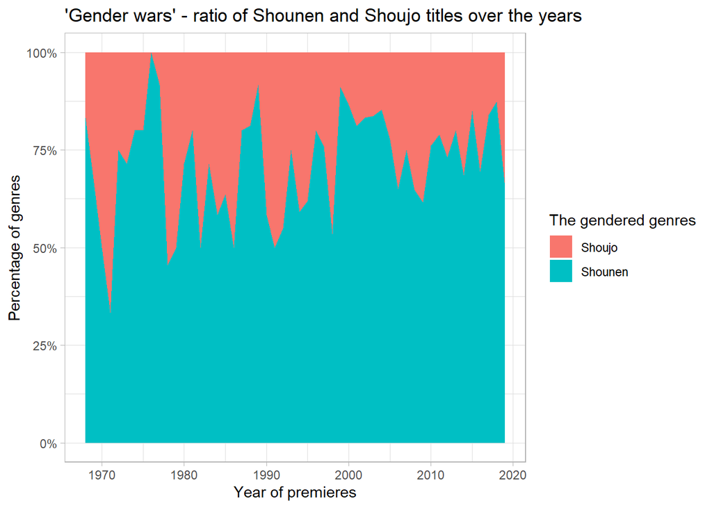

There is an interesting pattern here. If we look closely there are spikes of shoujo material starting at the beginning of decades, then there are other “spikes” at the middle and the end of decades. Although, in the 1970’s this mostly means a 1 or 2 difference, as there were small amount of animes releasing.

## 4. Genre “fingerprint” of studios

Based on the TidyTuesday screencast (https://www.youtube.com/watch?v=EHqFDXa-sH4), I will try to find out whether there are any distinguishable or meaningful profiles of different popular animating studios. For animes, usually a studio name is very telling for fans, much like in Hollywood, where for instance you know that Blumhouse equals horrors and A24 equals arthouse. Let’s find out these typicalities.

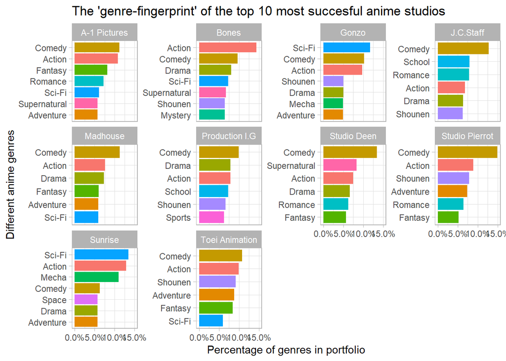

```
## # A tibble: 10 x 4
##    studio         name                                   scored_by max_scored
##    <fct>          <chr>                                      <dbl>      <dbl>
##  1 A-1 Pictures   Sword Art Online                         1007035    1007035
##  2 Bones          Fullmetal Alchemist: Brotherhood          826899     826899
##  3 Gonzo          Rosario to Vampire                        245586     245586
##  4 J.C.Staff      Toradora!                                 612497     612497
##  5 Madhouse       Death Note                               1107955    1107955
##  6 Production I.G Psycho-Pass                               413239     413239
##  7 Studio Deen    Kono Subarashii Sekai ni Shukufuku wo!    431194     431194
##  8 Studio Pierrot Tokyo Ghoul                               745530     745530
##  9 Sunrise        Code Geass: Hangyaku no Lelouch           681621     681621
## 10 Toei Animation One Piece                                 465454     465454
```

Interestingly, most studios have “comedy” in a very high ratio. This is probably due to the fact that these studios need to produce low-effort, highly successful shows (which comedies are, i.e. sitcoms in the West) to gather money for bigger projects.

## 5 Is anime for children?

We have data about the age rating of the shows, so we could visualize whether the highest scored or most popular animes are rated for children or above.

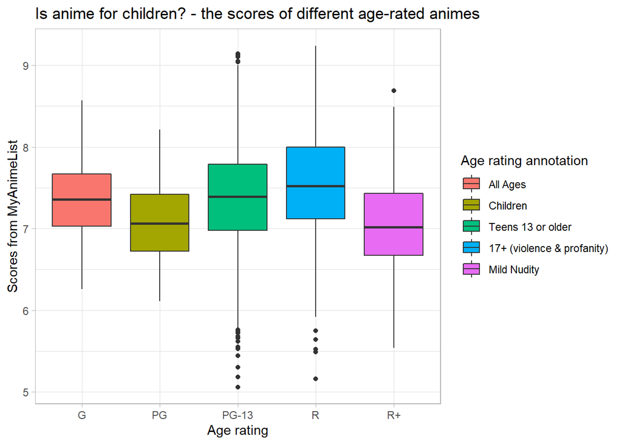

It appears that animes are scored better the more mature they get, but when it involves nudity and gets the R+ rating, the score declines. The best animes according to scores are rated R or PG-13, which include the teens and young adult oriented shows, who are the major part of the audience. Based on the figures, animes are appreciated more when they are not for children and involve more mature conflicts.

## 6. Are there seasonal trends in terms of narratives?

For this analysis, I use the approach taken from the TidyTuesday screencast (https://www.youtube.com/watch?v=3PecUbnuYC4), whereby one can use TidyText to tokenize running text and investigate the vocabulary and word usage of certain groups. I will check whether there exists any trend that could differentiate the word usage of anime description starting in different seasons. E.g. one could expect to have more grim animes for the winter, or more lighthearted ones for the summer.

After proper cleaning we can start the tokenization

```
## # A tibble: 177,080 x 3
##    name         premiere_season word
##    <chr>        <chr>           <chr>
##  1 Cowboy Bebop Spring          2071
##  2 Cowboy Bebop Spring          humanity
##  3 Cowboy Bebop Spring          colonized
##  4 Cowboy Bebop Spring          planets
##  5 Cowboy Bebop Spring          moons
##  6 Cowboy Bebop Spring          solar
##  7 Cowboy Bebop Spring          system
##  8 Cowboy Bebop Spring          leaving
##  9 Cowboy Bebop Spring          uninhabitable
## 10 Cowboy Bebop Spring          surface
## # ... with 177,070 more rows
```

```
## # A tibble: 48,602 x 3
##    premiere_season word       n
##    <chr>           <chr>  <int>
##  1 Spring          world    503
##  2 Fall            world    443
##  3 Spring          school   385
##  4 Fall            school   372
##  5 Spring          life     337
##  6 Summer          school   309
##  7 Fall            life     305
##  8 Winter          school   278
##  9 Winter          world    265
## 10 Spring          girl     261
## # ... with 48,592 more rows
```

After tokenizing the text and getting the words from each synopsis of each anime of each season, I can start visualizing the main question. Based on the video above, I will calculate a log odds ratio, that reveals which words are the most frequent in each of the seasons relative to the others. I will visualize the top 10 words of each season.

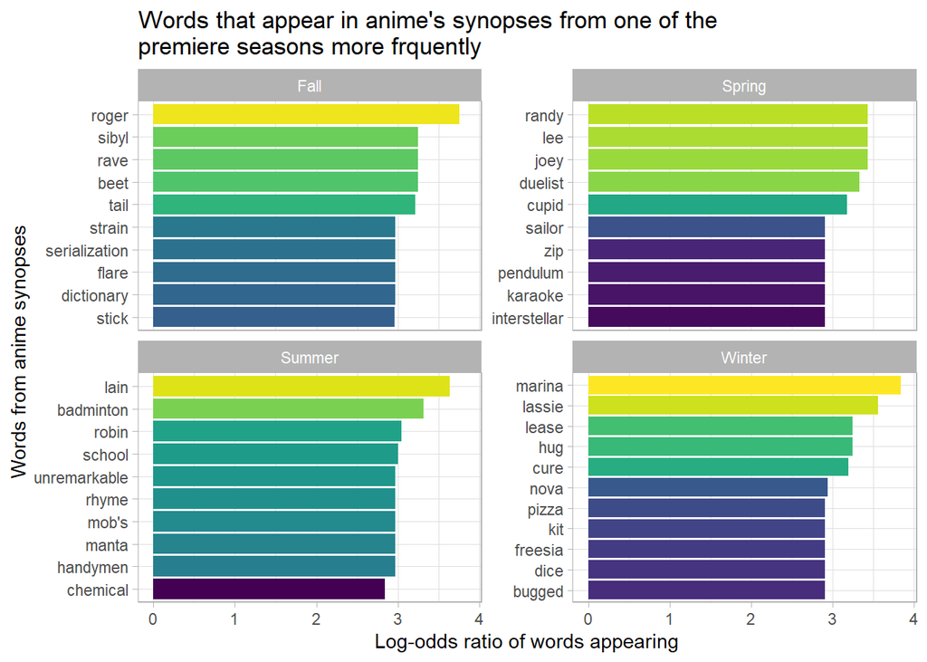

After proper cleaning, the data still does not show any real observable trends. Many of the words are English names that appear in some animes that premiered in one of the seasons. There are some interesting observation though: - Lain stands out for instance in summer, as it is a very rare name, and is the name of a protagonist of Serial Experiment Lain which released in the summer. - school is a very frequent word, yet it has a clear trend appearing in the summer, even though there is school’s out in Japan too from July to September. - Summer also has badminton a very “summer-y” sport

Altogether, this data does not really show too many interesting observations, due to the premiere seasons not being too distinctive, only in terms of name usage.

# Modelling

For modelling, I ask question that is probably the most interesting for any studios or aspiring anime creators: “What makes anime succesful?”

Being successful in this data means, that many people added this anime to their list (members). Although there is a “popularity” metric in the dataset, it is an ordinal scale, with one value for each anime, which is not suitable for such analysis.

To answer this question, we construct a model based on some theoretical approaches: - We would like to see whether the number of members putting the anime on their list is dependant on these variables: Score (how well it is rated - better more popular?), Premiere_season (in which season it premiered), Diversity (how many genres it is listed under), Rating (age rating of anime - related to figure 5.). I use these variables and Score as independent ones to predict Popularity.

I build the model first

```
##
## Call:
## lm(formula = members ~ premiere_season + diversity + rating +
##     score, data = anime_cleaned_model)
##
## Residuals:
##      Min       1Q   Median       3Q      Max
## -2.98898 -0.64764  0.02754  0.70410  2.66908
##
## Coefficients:
##                                      Estimate Std. Error t value Pr(>|t|)
## (Intercept)                          2.877652   0.304975   9.436  < 2e-16 ***
## premiere_seasonSpring                0.006046   0.059697   0.101  0.91934
## premiere_seasonSummer                0.186277   0.067144   2.774  0.00559 **
## premiere_seasonWinter                0.136029   0.068469   1.987  0.04711 *
## diversity                            0.073843   0.015739   4.692 2.93e-06 ***
## ratingPG-13 - Teens 13 or older      1.314248   0.126281  10.407  < 2e-16 ***
## ratingPG - Children                  0.689940   0.171378   4.026 5.93e-05 ***
## ratingR - 17+ (violence & profanity) 1.674860   0.134229  12.478  < 2e-16 ***
## ratingR+ - Mild Nudity               1.858016   0.148543  12.508  < 2e-16 ***
## score                                0.892498   0.037261  23.952  < 2e-16 ***
## ---
## Signif. codes:  0 '***' 0.001 '**' 0.01 '*' 0.05 '.' 0.1 ' ' 1
##
## Residual standard error: 0.9563 on 1690 degrees of freedom
## Multiple R-squared:  0.3524, Adjusted R-squared:  0.349
## F-statistic: 102.2 on 9 and 1690 DF,  p-value: < 2.2e-16
```

### Checking for influential outliers

Check for outlier values in the model.

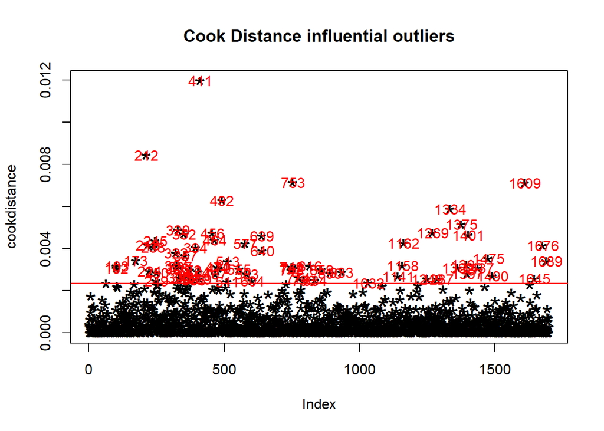

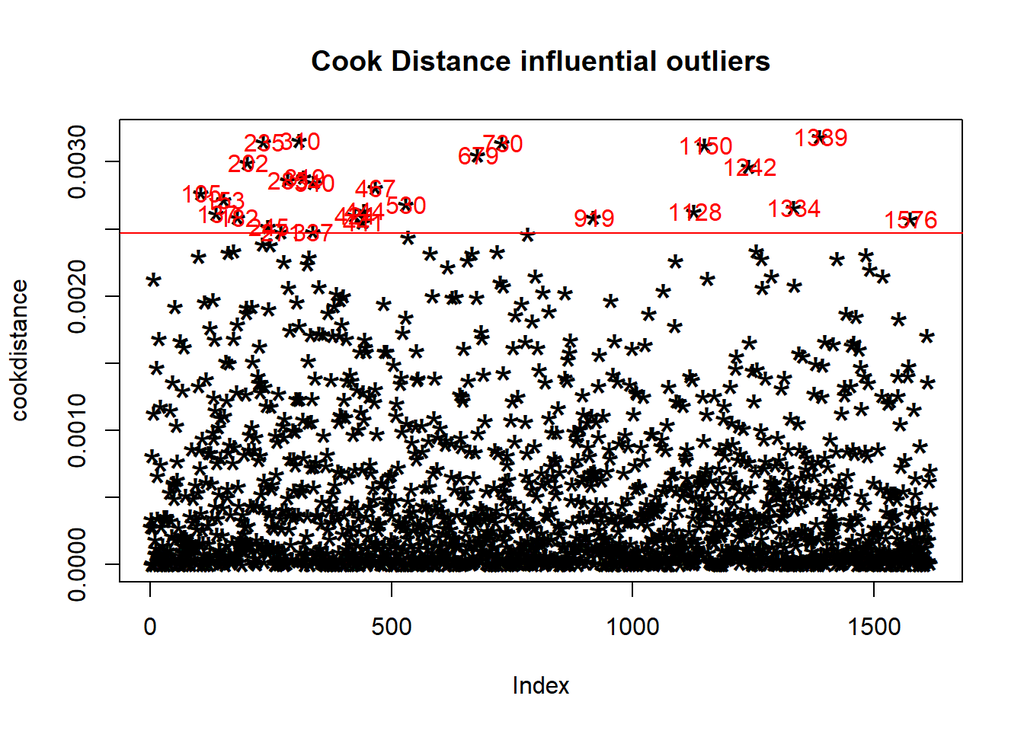

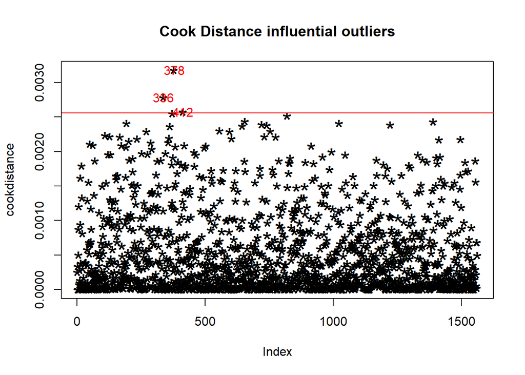

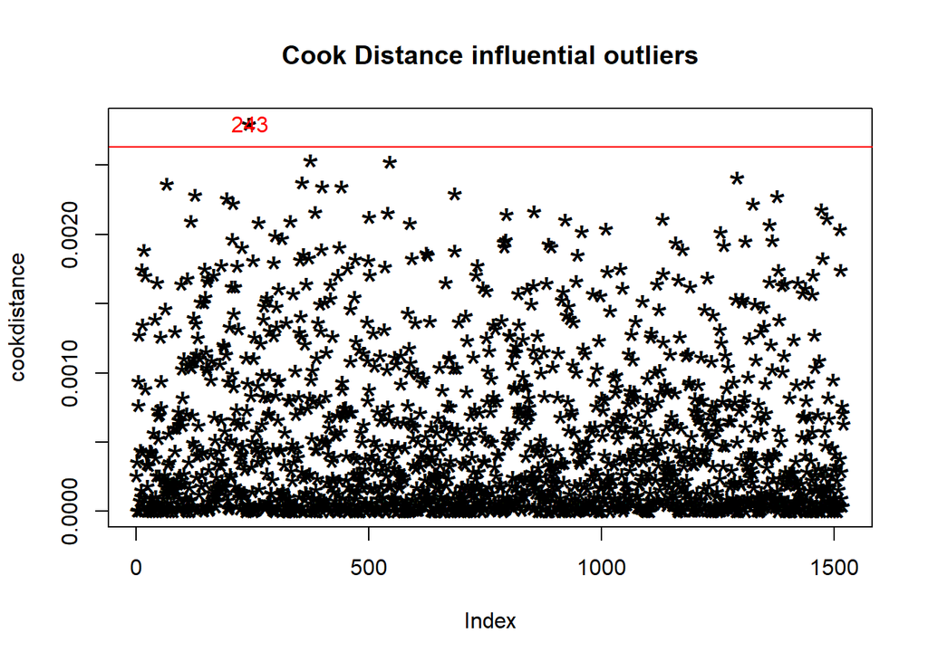

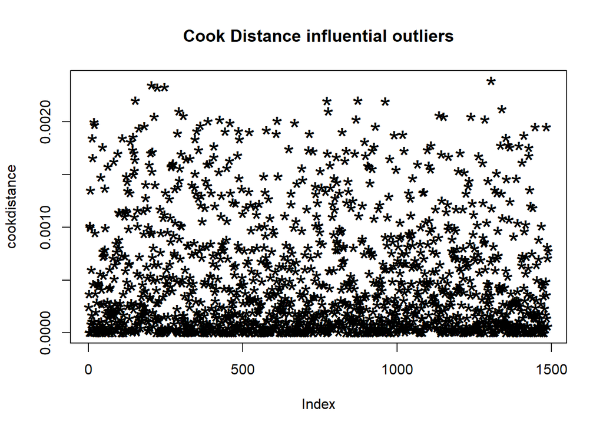

### Checking assumptions

Check the normality assumption.

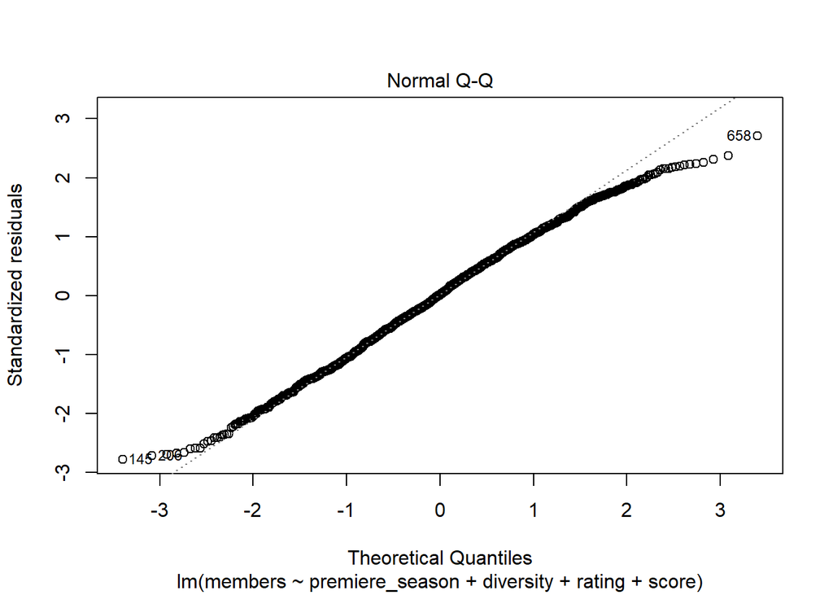

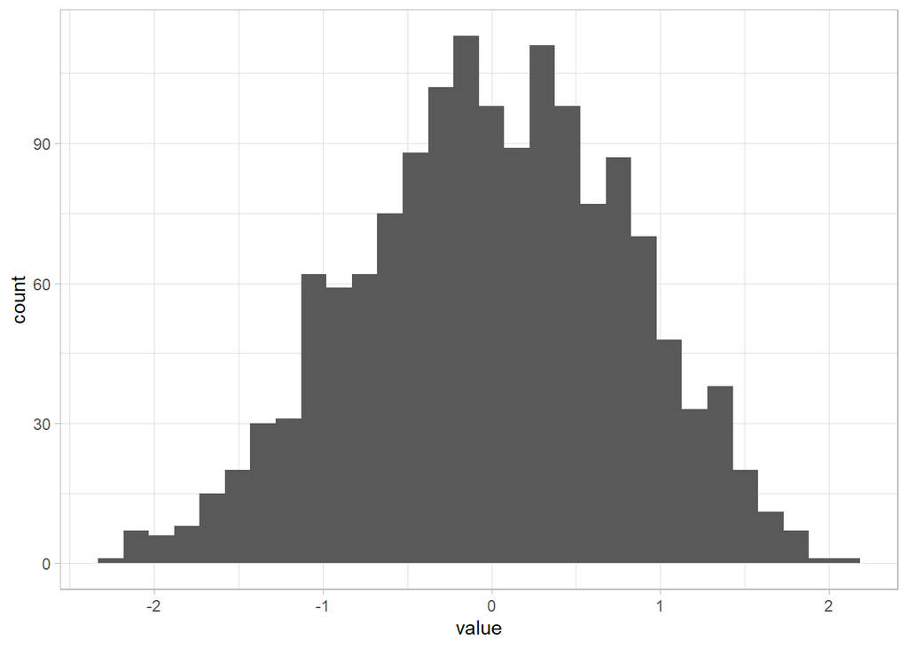

Check the linearity assumption.

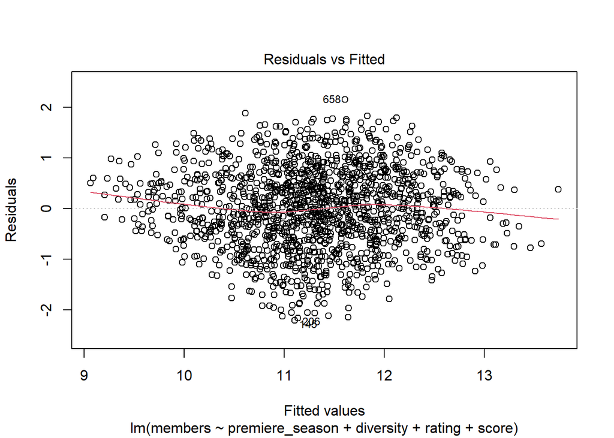

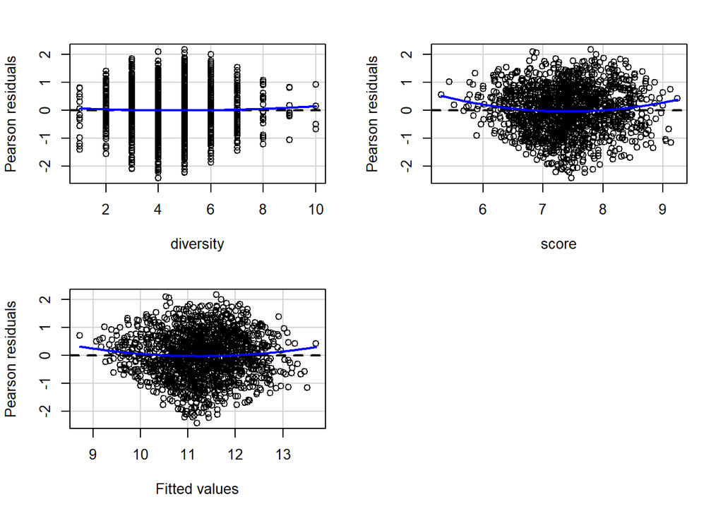

```
##            Test stat Pr(>|Test stat|)
## diversity     0.7897         0.429820
## score         3.2264         0.001281 **
## Tukey test    2.3047         0.021183 *
## ---
## Signif. codes:  0 '***' 0.001 '**' 0.01 '*' 0.05 '.' 0.1 ' ' 1
```

```
##
## Call:
## lm(formula = members ~ premiere_season + diversity + rating +
##     poly(score), data = anime_cleaned_model)
##
## Residuals:
##      Min       1Q   Median       3Q      Max
## -2.98898 -0.64764  0.02754  0.70410  2.66908
##
## Coefficients:
##                                       Estimate Std. Error t value Pr(>|t|)
## (Intercept)                           9.456731   0.144438  65.473  < 2e-16 ***
## premiere_seasonSpring                 0.006046   0.059697   0.101  0.91934
## premiere_seasonSummer                 0.186277   0.067144   2.774  0.00559 **
## premiere_seasonWinter                 0.136029   0.068469   1.987  0.04711 *
## diversity                             0.073843   0.015739   4.692 2.93e-06 ***
## ratingPG-13 - Teens 13 or older       1.314248   0.126281  10.407  < 2e-16 ***
## ratingPG - Children                   0.689940   0.171378   4.026 5.93e-05 ***
## ratingR - 17+ (violence & profanity)  1.674860   0.134229  12.478  < 2e-16 ***
## ratingR+ - Mild Nudity                1.858016   0.148543  12.508  < 2e-16 ***
## poly(score)                          23.711277   0.989933  23.952  < 2e-16 ***
## ---
## Signif. codes:  0 '***' 0.001 '**' 0.01 '*' 0.05 '.' 0.1 ' ' 1
##
## Residual standard error: 0.9563 on 1690 degrees of freedom
## Multiple R-squared:  0.3524, Adjusted R-squared:  0.349
## F-statistic: 102.2 on 9 and 1690 DF,  p-value: < 2.2e-16
```

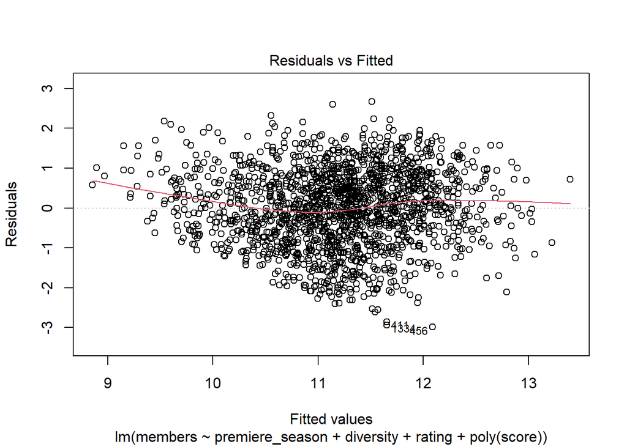

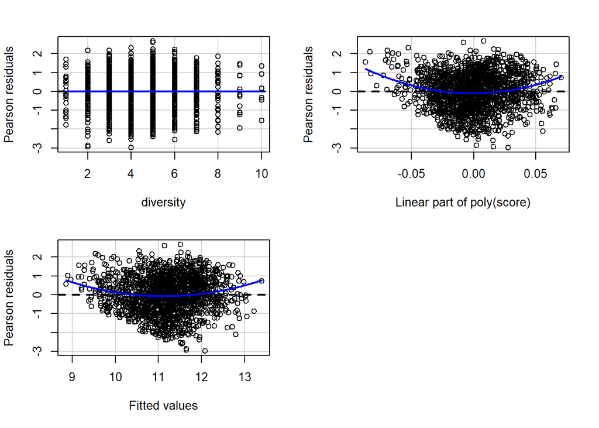

```
##             Test stat Pr(>|Test stat|)
## diversity     -0.0575           0.9541
## poly(score)
## Tukey test     5.7290         1.01e-08 ***
## ---
## Signif. codes:  0 '***' 0.001 '**' 0.01 '*' 0.05 '.' 0.1 ' ' 1
```

## Updating model

As I removed Score from the independent variables, I will reconstruct the model, and rerun the diagnostics before prceeding.

```
##
## Call:
## lm(formula = members ~ premiere_season + diversity + rating,
##     data = anime_cleaned_model)
##
## Residuals:
##      Min       1Q   Median       3Q      Max
## -2.94048 -0.80037  0.02479  0.76929  3.11164
##
## Coefficients:
##                                      Estimate Std. Error t value Pr(>|t|)
## (Intercept)                           9.31294    0.16697  55.775  < 2e-16 ***
## premiere_seasonSpring                -0.03057    0.06905  -0.443   0.6581
## premiere_seasonSummer                 0.07849    0.07751   1.013   0.3114
## premiere_seasonWinter                 0.02404    0.07903   0.304   0.7611
## diversity                             0.12715    0.01803   7.053 2.54e-12 ***
## ratingPG-13 - Teens 13 or older       1.29750    0.14611   8.881  < 2e-16 ***
## ratingPG - Children                   0.37991    0.19772   1.921   0.0548 .
## ratingR - 17+ (violence & profanity)  1.76551    0.15524  11.372  < 2e-16 ***
## ratingR+ - Mild Nudity                1.49280    0.17096   8.732  < 2e-16 ***
## ---
## Signif. codes:  0 '***' 0.001 '**' 0.01 '*' 0.05 '.' 0.1 ' ' 1
##
## Residual standard error: 1.107 on 1691 degrees of freedom
## Multiple R-squared:  0.1326, Adjusted R-squared:  0.1285
## F-statistic: 32.31 on 8 and 1691 DF,  p-value: < 2.2e-16
```

### Checking for influential outliers

Check for outlier values in the model.

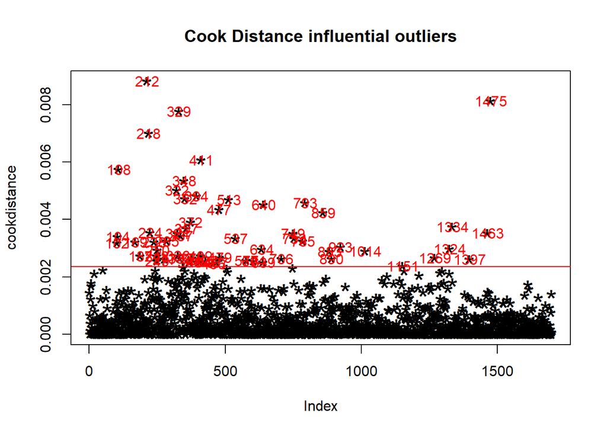

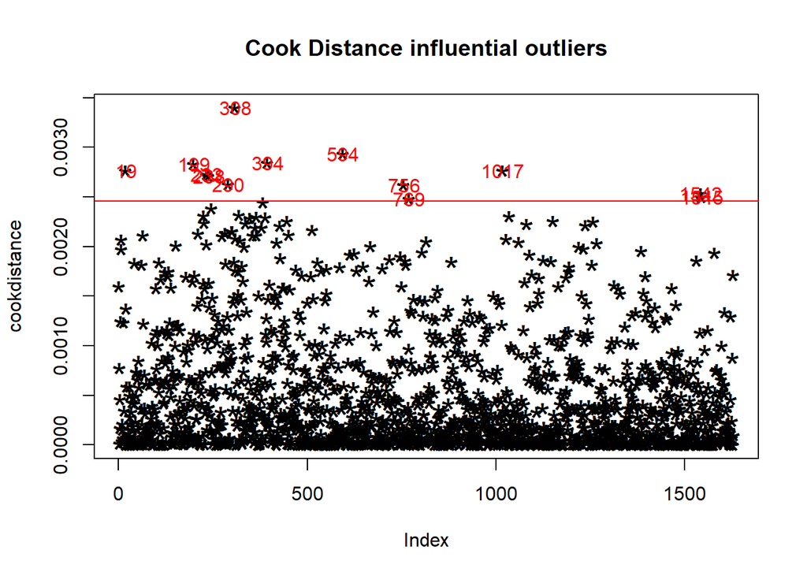

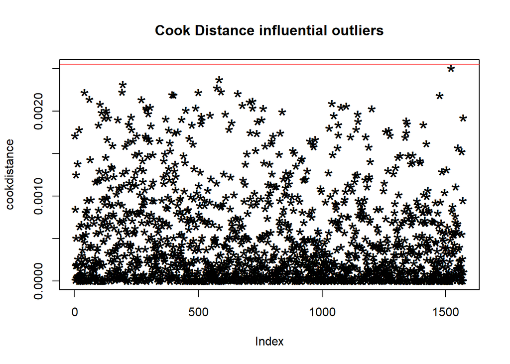

### Checking assumptions

Check the normality assumption.

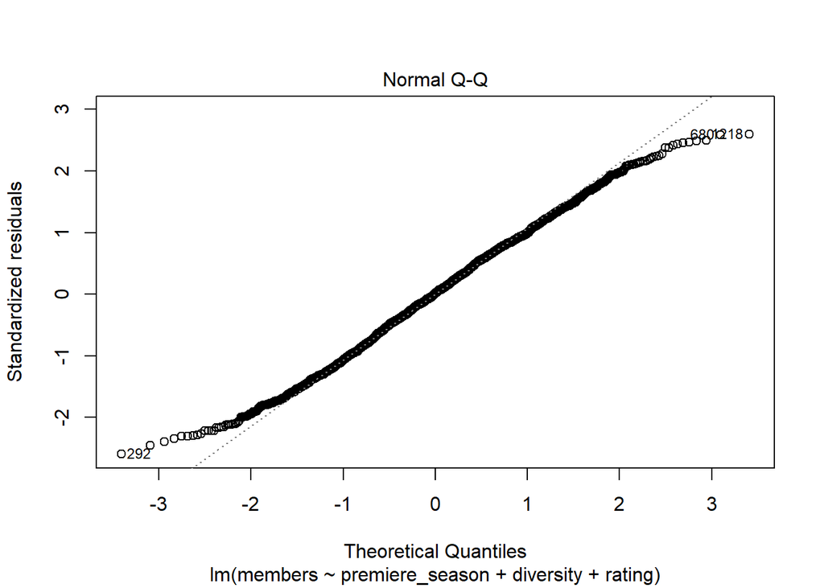

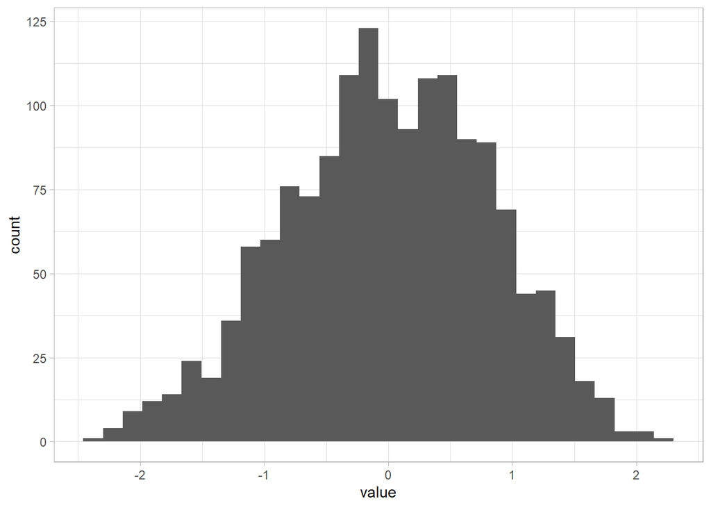

Check the linearity assumption.

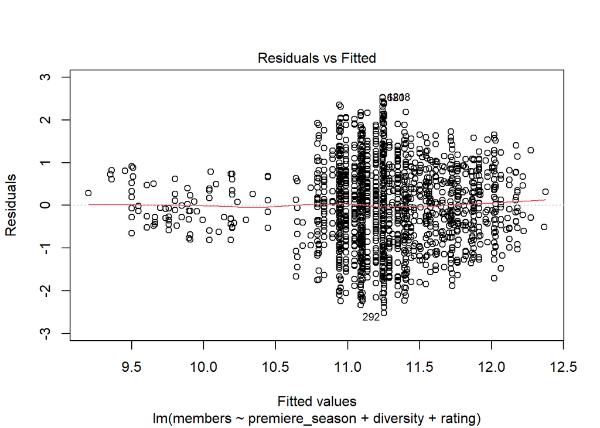

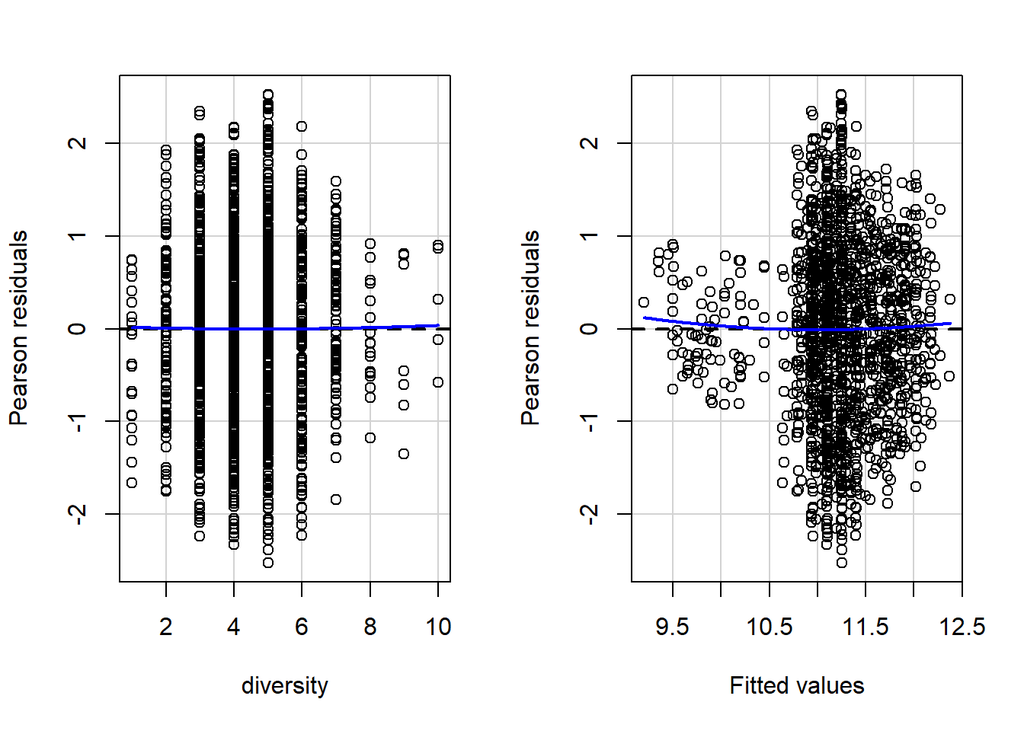

```
##            Test stat Pr(>|Test stat|)
## diversity     0.1757           0.8606
## Tukey test    1.6365           0.1017
```

Check the homoscedasticty assumption (homogeneity of variance).

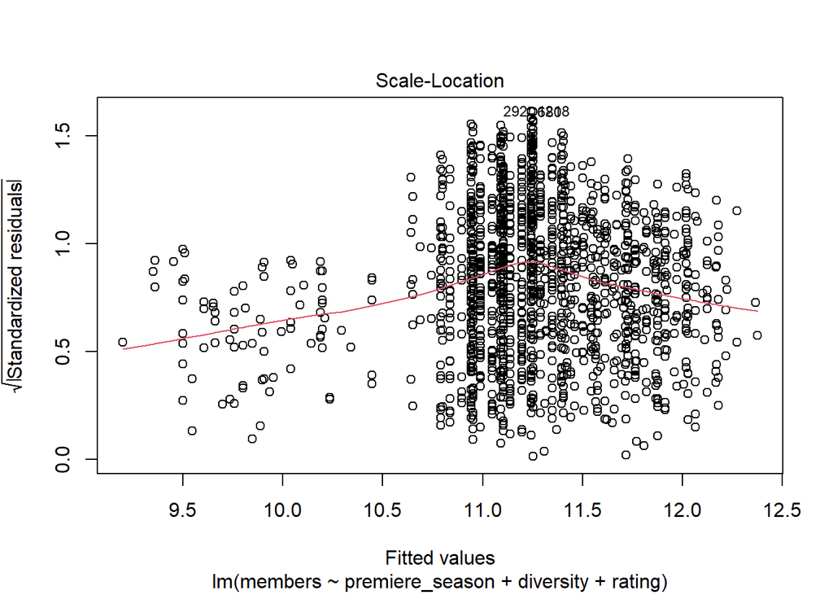

```
## Non-constant Variance Score Test
## Variance formula: ~ fitted.values
## Chisquare = 0.0003774342, Df = 1, p = 0.9845
```

```
##
##  studentized Breusch-Pagan test
##
## data:  .
## BP = 116.02, df = 8, p-value < 2.2e-16
```

Check the multicollinearity assumption.

(VIF above 5), or a VIF threshold of 3 is recommended in this paper: http://onlinelibrary.wiley.com/doi/10.1111/j.2041-210X.2009.00001.x/full

Some info about VIF: https://statisticalhorizons.com/multicollinearity http://blog.minitab.com/blog/understanding-statistics/handling-multicollinearity-in-regression-analysis

```
##                     GVIF Df GVIF^(1/(2*Df))
## premiere_season 1.023206  3        1.003831
## diversity       1.058066  1        1.028623
## rating          1.071013  4        1.008612
```

## Reporting and evaluating the model

I created the model based on the results of the model diagnostics. I now report the results for the model:

```
##
## Call:
## lm(formula = members ~ premiere_season + diversity + rating,
##     data = anime_cleaned_model_outlierrm_noscore3)
##
## Residuals:
##      Min       1Q   Median       3Q      Max
## -2.52614 -0.70041  0.01689  0.70057  2.52957
##
## Coefficients:
##                                       Estimate Std. Error t value Pr(>|t|)
## (Intercept)                           9.058103   0.168307  53.819   <2e-16 ***
## premiere_seasonSpring                -0.009487   0.063874  -0.149   0.8819
## premiere_seasonSummer                 0.036952   0.071579   0.516   0.6058
## premiere_seasonWinter                 0.095434   0.073789   1.293   0.1961
## diversity                             0.150823   0.017582   8.578   <2e-16 ***
## ratingPG-13 - Teens 13 or older       1.440728   0.150387   9.580   <2e-16 ***
## ratingPG - Children                   0.386846   0.216041   1.791   0.0736 .
## ratingR - 17+ (violence & profanity)  2.064424   0.158951  12.988   <2e-16 ***
## ratingR+ - Mild Nudity                1.808226   0.175644  10.295   <2e-16 ***
## ---
## Signif. codes:  0 '***' 0.001 '**' 0.01 '*' 0.05 '.' 0.1 ' ' 1
##
## Residual standard error: 0.9739 on 1520 degrees of freedom
## Multiple R-squared:  0.1952, Adjusted R-squared:  0.191
## F-statistic: 46.09 on 8 and 1520 DF,  p-value: < 2.2e-16
```

```
##                                          Estimate Std. Error    t value
## premiere_seasonSpring                -0.009487334 0.06387369 -0.1485327
## premiere_seasonSummer                 0.036951836 0.07157876  0.5162402
## premiere_seasonWinter                 0.095434381 0.07378922  1.2933378
## diversity                             0.150823052 0.01758168  8.5784224
## ratingPG-13 - Teens 13 or older       1.440728009 0.15038742  9.5801101
## ratingPG - Children                   0.386846441 0.21604134  1.7906130
## ratingR - 17+ (violence & profanity)  2.064424491 0.15895056 12.9878400
## ratingR+ - Mild Nudity                1.808225921 0.17564377 10.2948481
##                                          Pr(>|t|)       2.5 %    97.5 %
## premiere_seasonSpring                8.819420e-01 -0.13477723 0.1158026
## premiere_seasonSummer                6.057617e-01 -0.10345176 0.1773554
## premiere_seasonWinter                1.960908e-01 -0.04930508 0.2401738
## diversity                            2.333855e-17  0.11633614 0.1853100
## ratingPG-13 - Teens 13 or older      3.781620e-21  1.14573919 1.7357168
## ratingPG - Children                  7.355436e-02 -0.03692425 0.8106171
## ratingR - 17+ (violence & profanity) 1.183052e-36  1.75263884 2.3762101
## ratingR+ - Mild Nudity               4.494369e-24  1.46369612 2.1527557
##                                                 b         beta
## premiere_seasonSpring                -0.009487334 -0.004046613
## premiere_seasonSummer                 0.036951836  0.013757922
## premiere_seasonWinter                 0.095434381  0.034194548
## diversity                             0.150823052  0.203039588
## ratingPG-13 - Teens 13 or older       1.440728009  0.616656460
## ratingPG - Children                   0.386846441  0.055636968
## ratingR - 17+ (violence & profanity)  2.064424491  0.739692151
## ratingR+ - Mild Nudity                1.808225921  0.437036557
```

# Conclusions

## Exploratory analysis

Visualizing the anime datasets, we saw some interesting trends:

1. The most scored and most favorited animes on MyAnimeList have some overlaps, although most of them have different ranks between these measures.
2. There are clearly animes that are either more popular than ranked or vice versa.
3. Shounen animes are produced at increasing rates, however there are years, when Shoujo animes get produced more than usually.
4. Studios can be differentiated by the genres they produce mostly, and it is mirrored in their most succesful animes.
5. Animes for more mature audiences are better scored, but too mature animes are not.
6. There are no real observable trends of anime synopses using distinct vocabulary based on the premiere season.

## Modelling

For the modelling part, there were some limitations. The dependent varaible was log transformed, so we may have lost some precision in our prediction. There were also many categorical independent variables, which introduced a great amount of df, which made the model less precise and robust.

It is also a bit hard to explain the findings, but we can infer some conclusions: - The diversity of an anime significantly predicts receiveng more traction/popularity, meaning that the more genre an anime blends, the more popular it can get. - A higher age rating than Children significantly predicts an anime getting more popular - animes for Teen and Mature receive more viewings from people on MyAnimeList.org